# ggplot2 live coding script

## Facets

A useful feature of ggplot2 is faceting. This allows you to split your plot into subplots, or facets, based on one or more categorical variables. Each subplot displays a subset of the data.

There are two faceting functions, `facet_grid` and `facet_wrap`.

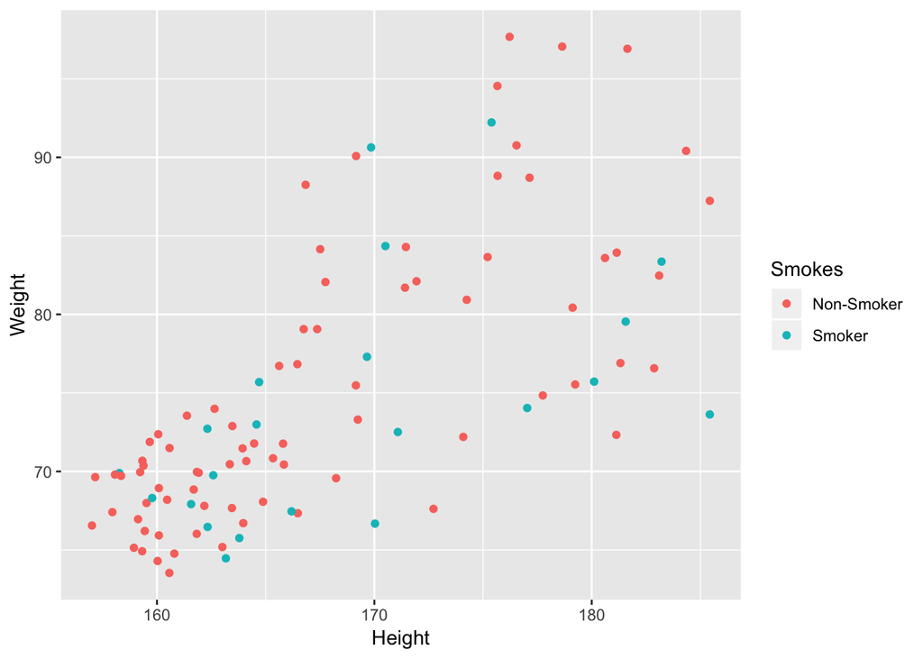

```r
ggplot(data = patients, mapping = aes(x = Height, y = Weight, colour = Smokes)) +
  geom_point()
```

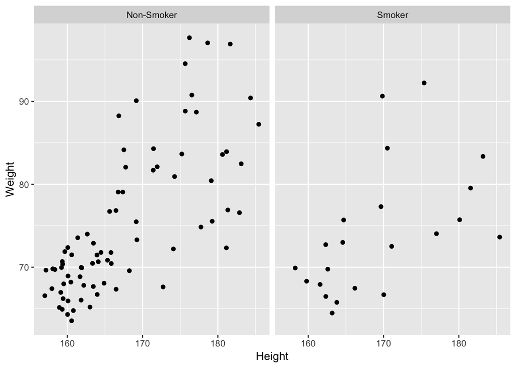

```r
ggplot(data = patients, mapping = aes(x = Height, y = Weight)) +
  geom_point() +
  facet_wrap(~ Smokes)
```

The `~ Smokes` argument provided to `facet_wrap` is known as a formula in R. Formulae are used to build models in R.

Faceting is perhaps more useful when there are several categories helping to distinguish between them by seeing the data in separate subplots.

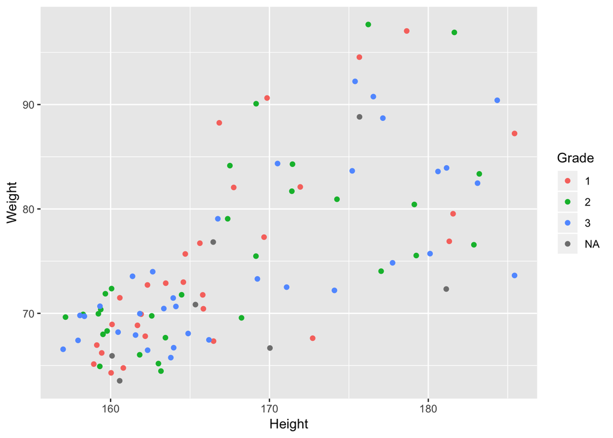

```r
ggplot(data = patients, mapping = aes(x = Height, y = Weight, colour = Grade)) +
  geom_point()
```

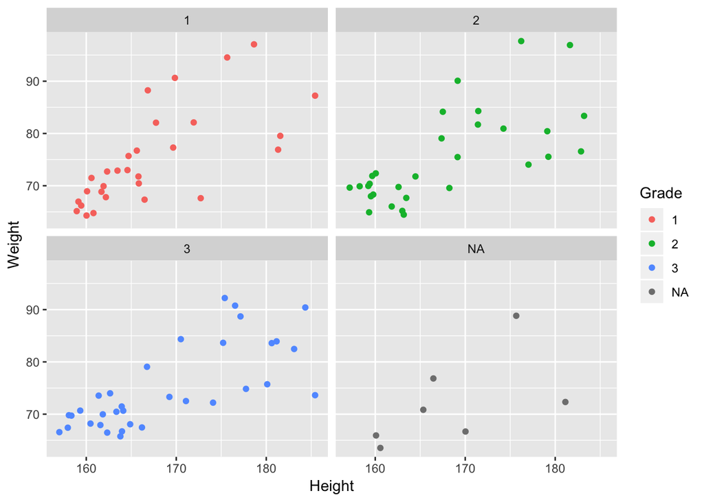

```r
ggplot(data = patients, mapping = aes(x = Height, y = Weight, colour = Grade)) +
  geom_point() +
  facet_wrap(~ Grade)
```

We can tell ggplot2 to fit the subplots onto a single row.

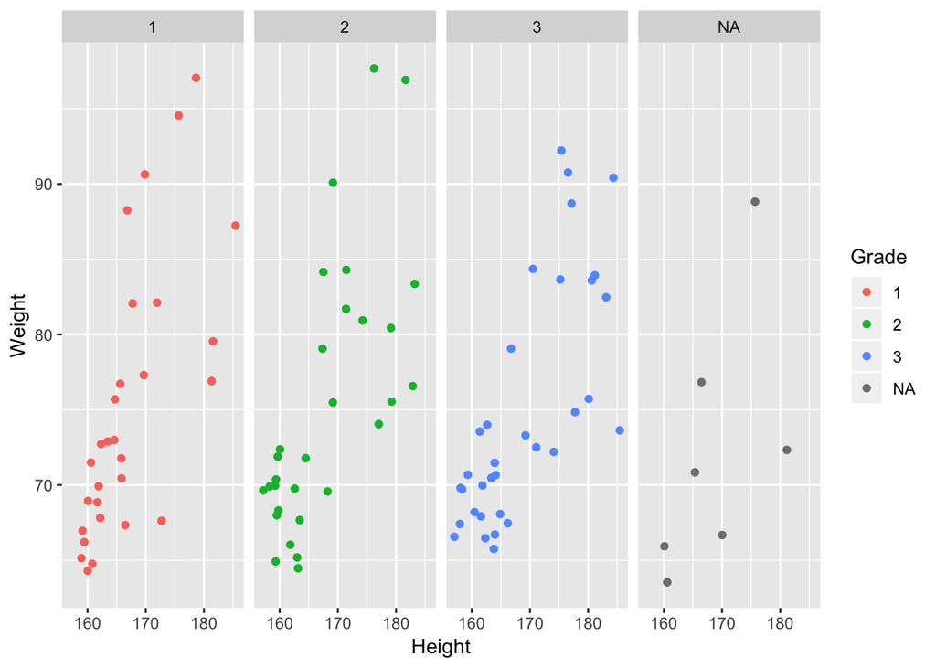

```r
ggplot(data = patients, mapping = aes(x = Height, y = Weight, colour = Grade)) +
  geom_point() +
  facet_wrap(~ Grade, nrow = 1)
```

Or we can force it to use a specified number of columns.

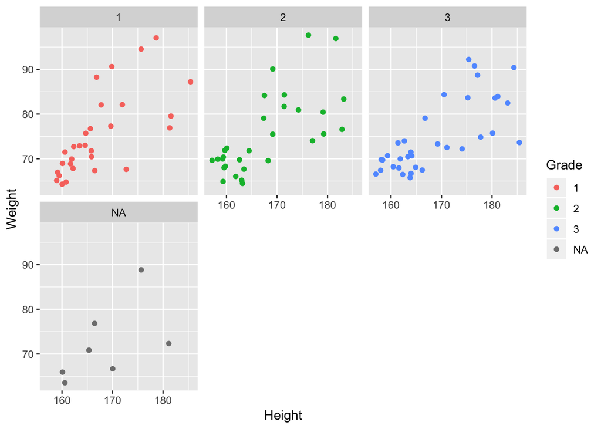

```r
ggplot(data = patients, mapping = aes(x = Height, y = Weight, colour = Grade)) +
  geom_point() +
  facet_wrap(~ Grade, ncol = 3)
```

Here you can see that it ‘wraps’ plots across more than one row if necessary.

We can facet on more than one variable.

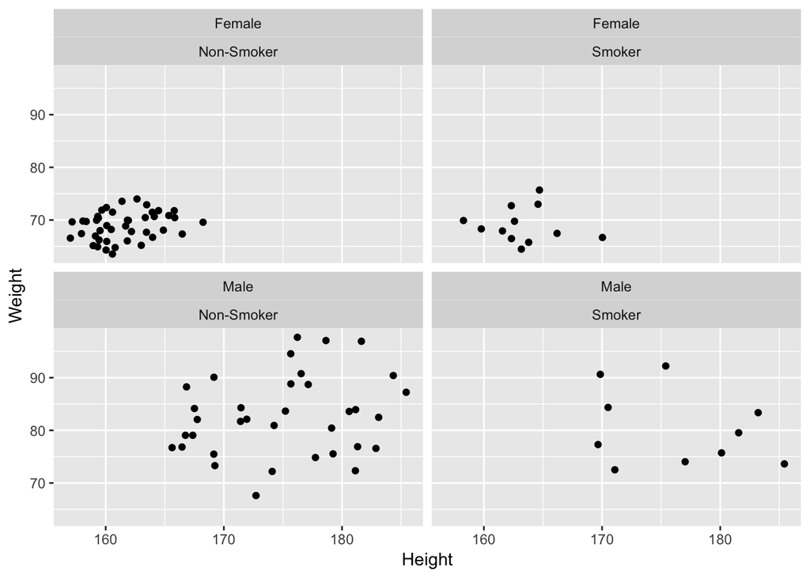

```r
ggplot(data = patients, mapping = aes(x = Height, y = Weight)) +
  geom_point() +
  facet_wrap(~ Sex + Smokes)
```

Faceting on two variables can also be done as a grid using `facet_grid` and arguably produces clearer labelling of the subplots.

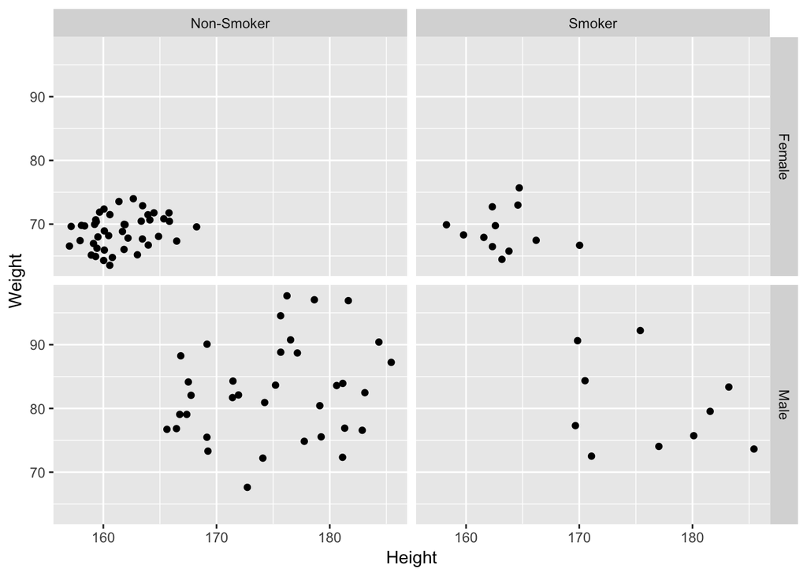

```r
ggplot(data = patients, mapping = aes(x = Height, y = Weight)) +
  geom_point() +
  facet_grid(Sex ~ Smokes)
```

Compare this with using a single plot and aesthetics.

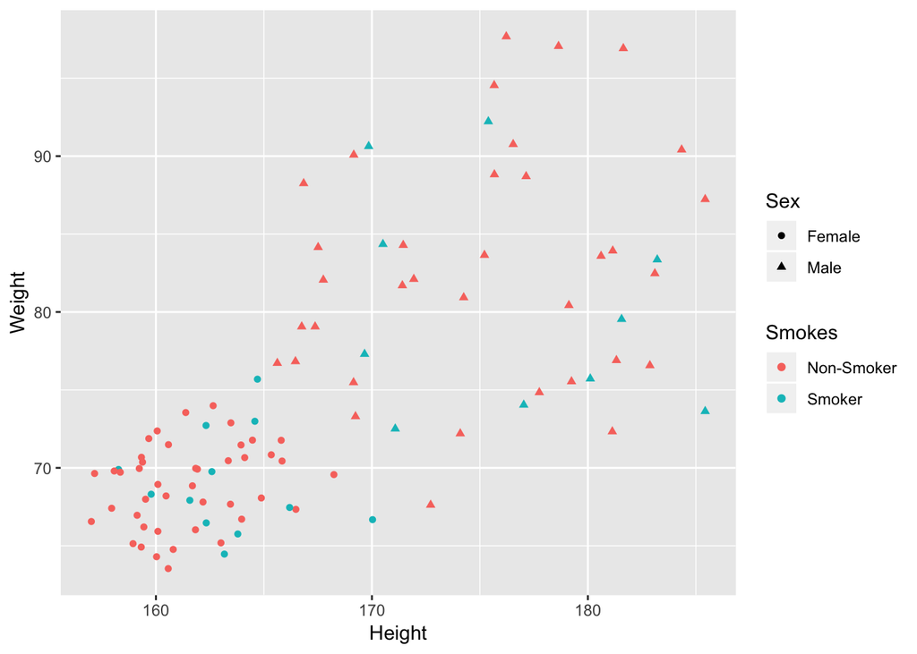

```r
ggplot(data = patients, mapping = aes(x = Height, y = Weight, colour = Smokes, shape = Sex)) +
  geom_point()
```

It is possible to only facet on one variable in either the rows or columns dimension using `facet_grid`.

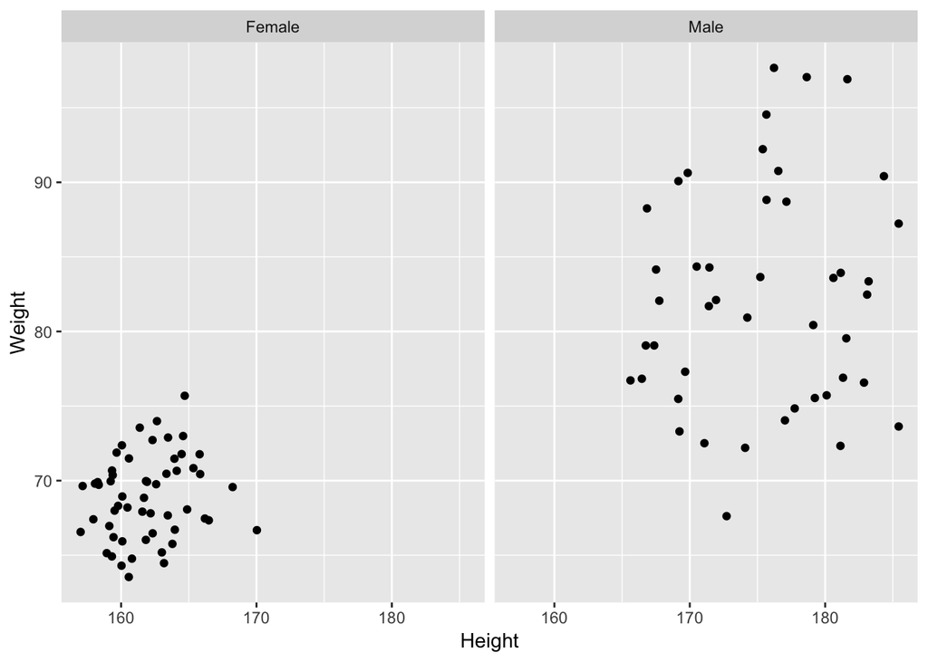

```r
ggplot(data = patients, mapping = aes(x = Height, y = Weight)) +
  geom_point() +
  facet_grid(. ~ Sex)
```

This is the same as using `facet_wrap` with `nrow = 1` so not terribly useful but if you want the plots to be stacked in a single column with labels down the sides then you can do the following.

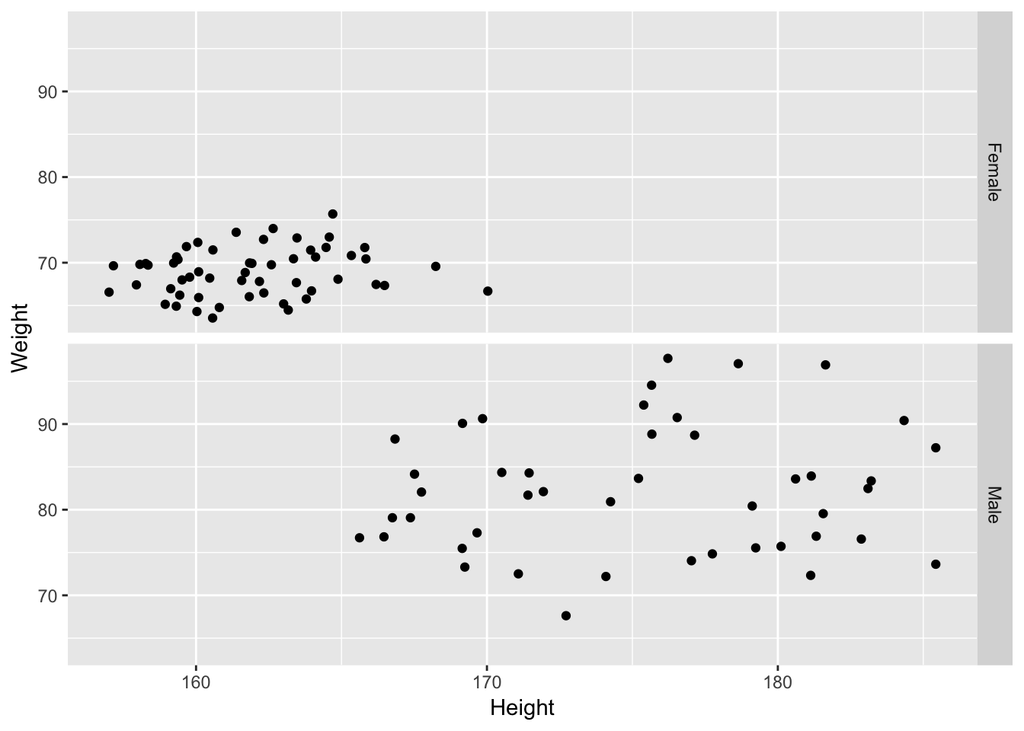

```r
ggplot(data = patients, mapping = aes(x = Height, y = Weight)) +
  geom_point() +
  facet_grid(Sex ~ .)
```

It is also possible to facet on more more than two variables with facet_wrap although usually this leads to very cluttered plots; it is probably better to stick to using one or two variables for faceting.

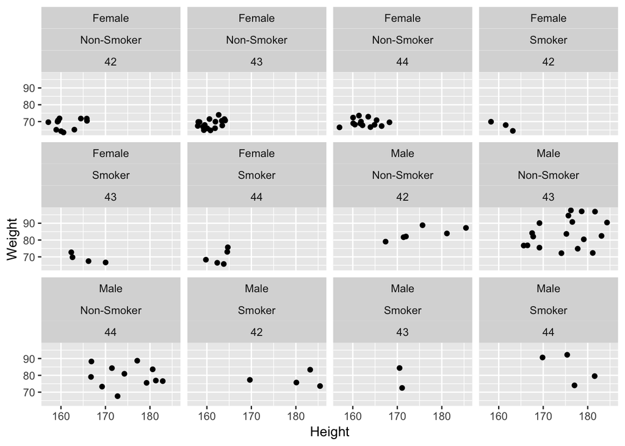

```r
ggplot(data = patients, mapping = aes(x = Height, y = Weight)) +
  geom_point() +
  facet_wrap(~ Sex + Smokes + Age)
```

We can use other aesthetic mappings for grouping data alongside faceting.

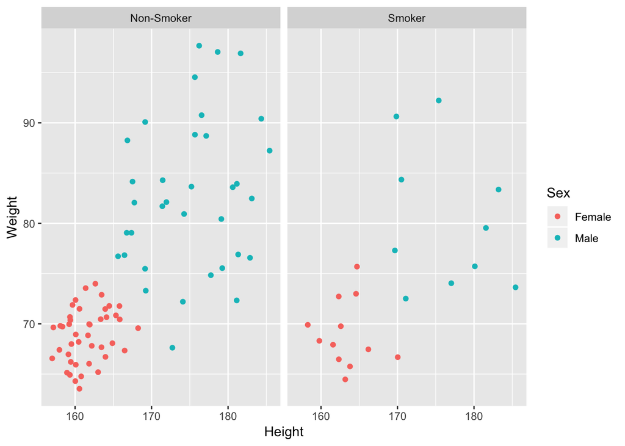

```r
ggplot(data = patients, mapping = aes(x = Height, y = Weight, colour = Sex)) +
  geom_point() +
  facet_wrap(~ Smokes)
```

## Exercises part II - faceets

See separate R markdown document.

## Customization

### Labels

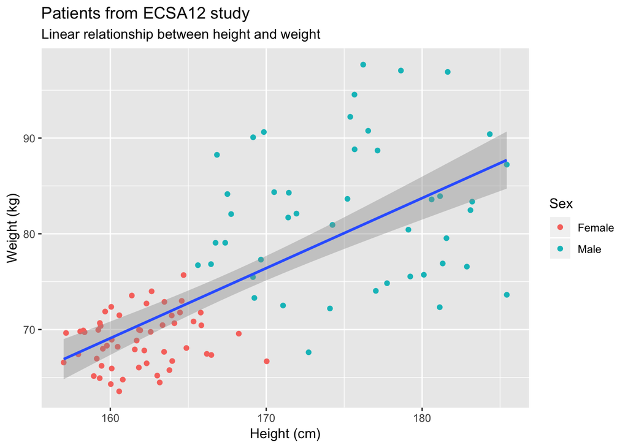

```r
ggplot(data = patients, mapping = aes(x = Height, y = Weight)) +
  geom_point(mapping = aes(colour = Sex)) +
  geom_smooth(method = "lm") +
  labs(
    title = "Patients from ECSA12 study",
    subtitle = "Linear relationship between height and weight",
    x = "Height (cm)",
    y = "Weight (kg)"
  )
```

### Scales

Take a look at the x and y scales in the above plot. ggplot2 has chosen the x and y scales and where to put breaks and ticks.

```r
plot <- ggplot(data = patients, mapping = aes(x = Height, y = Weight, colour = Sex)) +
  geom_point(mapping = aes(colour = Sex))
names(plot)
```

```
## [1] "data"        "layers"      "scales"      "mapping"     "theme"
## [6] "coordinates" "facet"       "plot_env"    "labels"
```

One of the components of the plot is called `scales`.

ggplot2 automatically adds default scales behind the scenes equivalent to the following:

```r
plot <- ggplot(data = patients, mapping = aes(x = Height, y = Weight, colour = Sex)) +
  geom_point() +
  scale_x_continuous() +
  scale_y_continuous() +
  scale_colour_discrete()
```

Note that we have three aesthetics and ggplot2 adds a scale for each.

```r
plot$mapping
```

[output not shown]

The x and y variables are continuous hence ggplot2 adds a continuous scale for each. Colour is a discrete variable in this case so ggplot2 adds a discrete scale for colour.

Generalizing, the scales that are required follow the naming scheme:

```
scale_<NAME_OF_AESTHETIC>_<NAME_OF_SCALE>
```

Look at the help pages to see what we can change about the y axis.

```r
?scale_y_continuous
```

We’re going to modify the scales for the following plot.

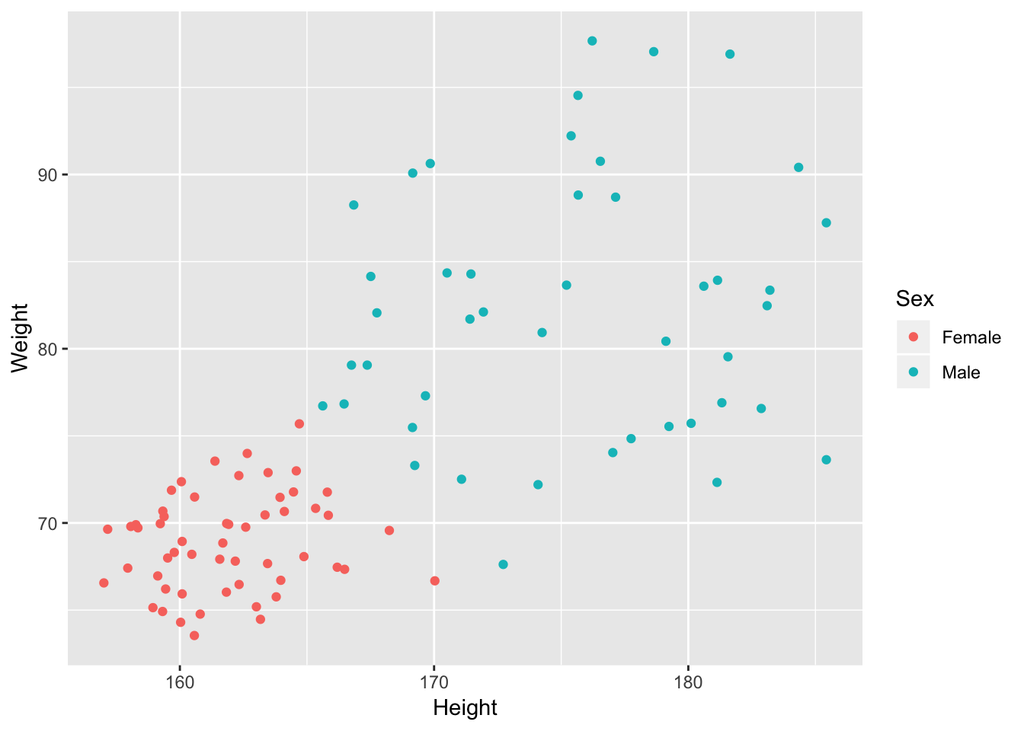

```r
ggplot(data = patients, mapping = aes(x = Height, y = Weight, colour = Sex)) +
  geom_point() +
  scale_y_continuous()
```

First, we’ll change the breaks, i.e. where ggplot2 puts ticks and numeric labels, on the y axis.

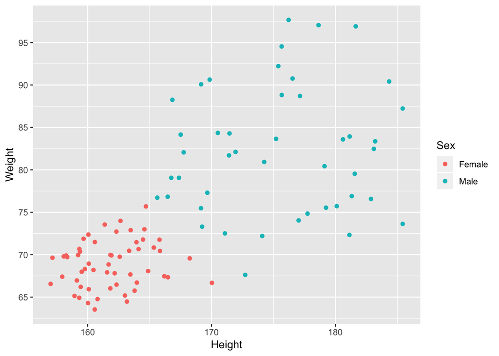

```r
ggplot(data = patients, mapping = aes(x = Height, y = Weight, colour = Sex)) +
  geom_point() +
  scale_y_continuous(breaks = seq(60, 100, by = 5))
```

We can also adjust the extents of the y axis.

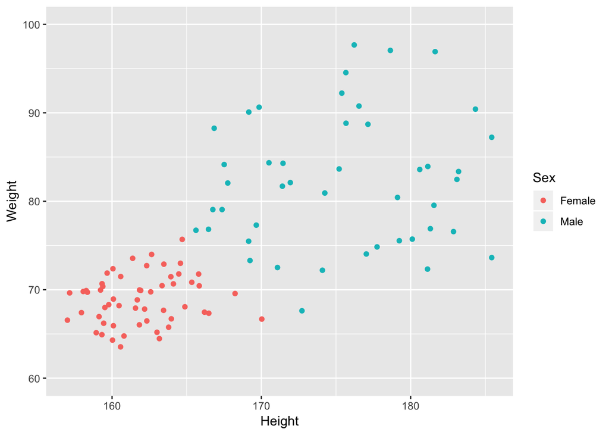

```r
ggplot(data = patients, mapping = aes(x = Height, y = Weight, colour = Sex)) +
  geom_point() +
  scale_y_continuous(limits = c(60, 100))
```

We can change the minor breaks, e.g. to add more lines that act as guides. These are shown as thin white lines when using the default theme (we’ll take a look at alternative themes a bit later).

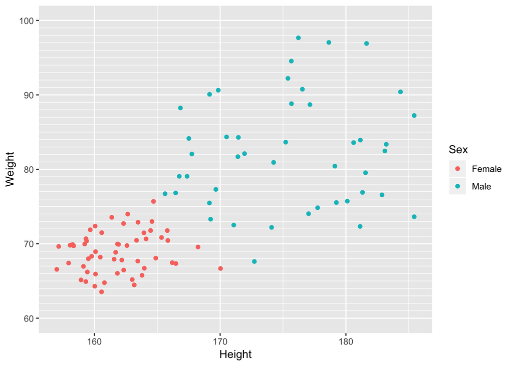

```r
ggplot(data = patients, mapping = aes(x = Height, y = Weight, colour = Sex)) +
  geom_point() +
  scale_y_continuous(limits = c(60, 100), minor_breaks = seq(60, 100, by = 1))
```

Or we can remove the minor breaks entirely.

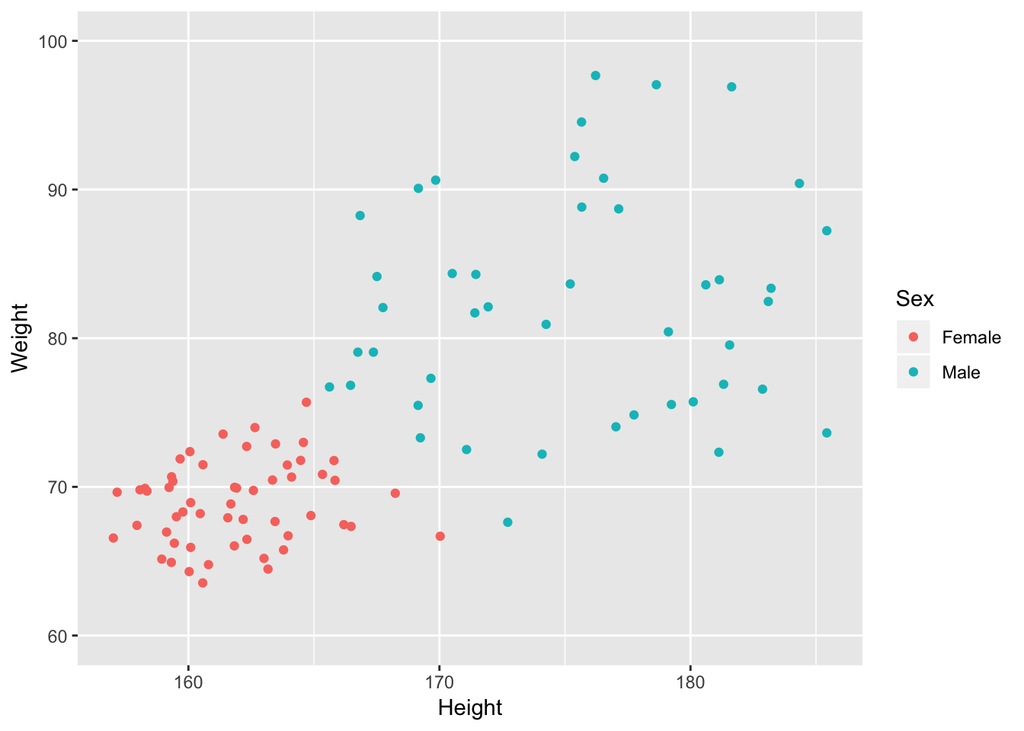

```r
ggplot(data = patients, mapping = aes(x = Height, y = Weight, colour = Sex)) +
  geom_point() +
  scale_y_continuous(limits = c(60, 100), minor_breaks = NULL)
```

Maybe we don’t want any breaks at all.

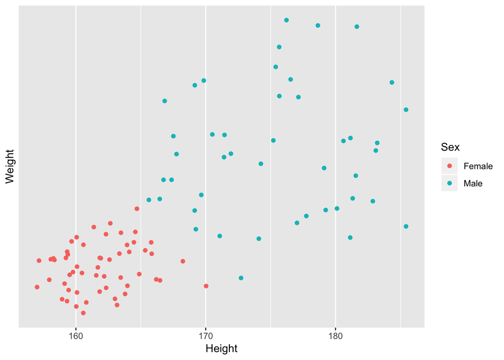

```r
ggplot(data = patients, mapping = aes(x = Height, y = Weight, colour = Sex)) +
  geom_point() +
  scale_y_continuous(breaks = NULL)
```

By default the scales are expanded by 5% of the range on either side. We can add more space round the edges.

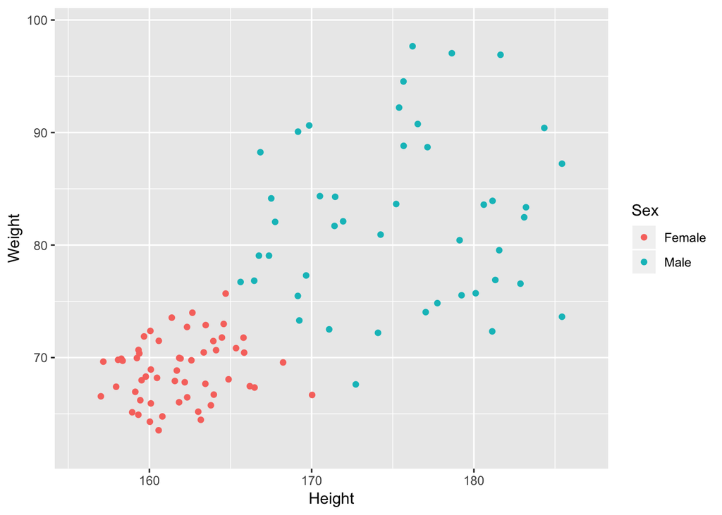

```r
ggplot(data = patients, mapping = aes(x = Height, y = Weight, colour = Sex)) +
  geom_point() +
  scale_x_continuous(expand = expand_scale(mult = 0.1)) +
  scale_y_continuous(expand = expand_scale(mult = 0.1))
```

We can move draw the axis on the other side of the plot – not sure why you’d want to do this but with ggplot2 just about anything is possible.

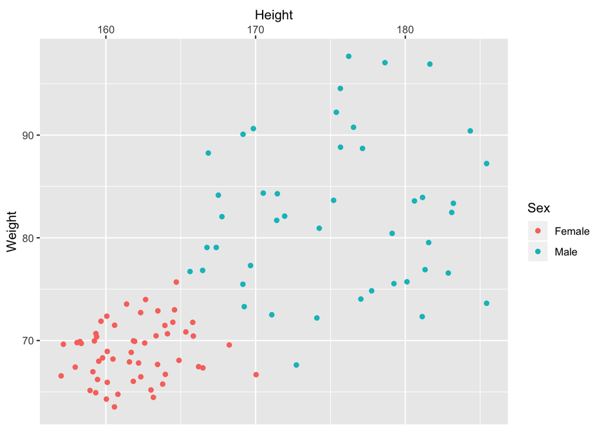

```r
ggplot(data = patients, mapping = aes(x = Height, y = Weight, colour = Sex)) +
  geom_point() +
  scale_x_continuous(position = "top")
```

### Colours

Use `scale_colour_manual` to manually set the colours for a categorical variable.

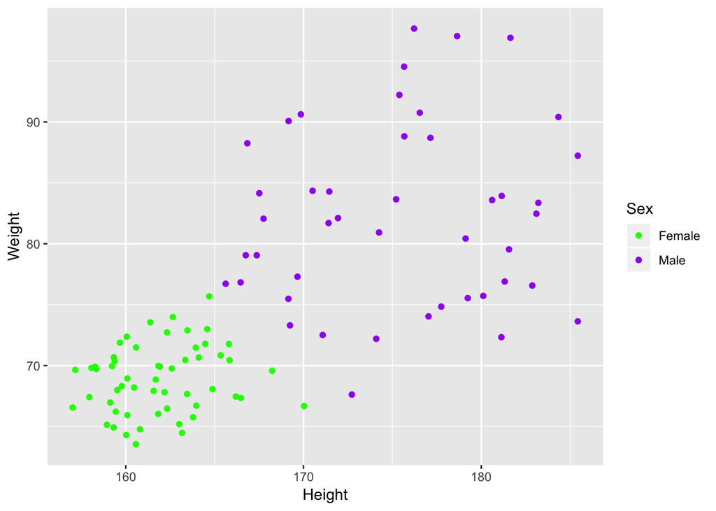

```r
ggplot(data = patients, mapping = aes(x = Height, y = Weight, colour = Sex)) +
  geom_point() +
  scale_colour_manual(values = c("green", "purple"))
```

ggplot2 provides a set of colour palettes from [ColorBrewer](http://colorbrewer2.org).

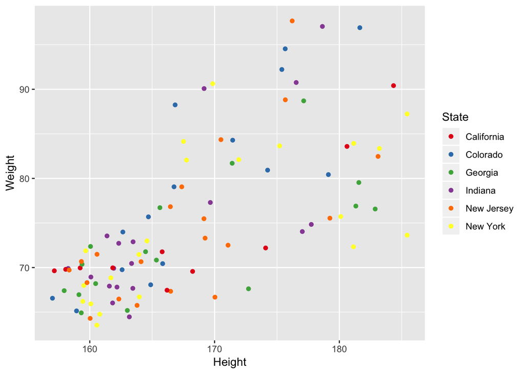

```r
ggplot(data = patients, mapping = aes(x = Height, y = Weight, colour = State)) +
  geom_point() +
  scale_colour_brewer(palette = "Set1")
```

Look at the help page for `scale_colour_brewer` to see what other colour palettes are available, then try some.

```r
?scale_colour_brewer
```

Interestingly you can set other attributes other than just the colours at the same time.

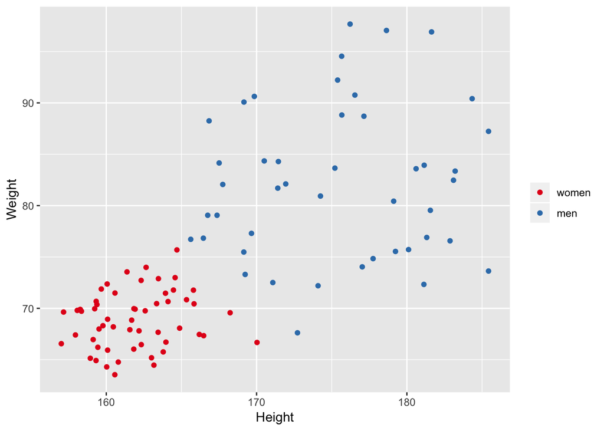

```r
ggplot(data = patients, mapping = aes(x = Height, y = Weight, colour = Sex)) +
  geom_point() +
  scale_colour_brewer(palette = "Set1", name = NULL, labels = c("women", "men"))
```

What you are doing here is setting your own set of mappings from levels in the data to aesthetic values.

You can select the colours used in a gradient for a continuous variable.

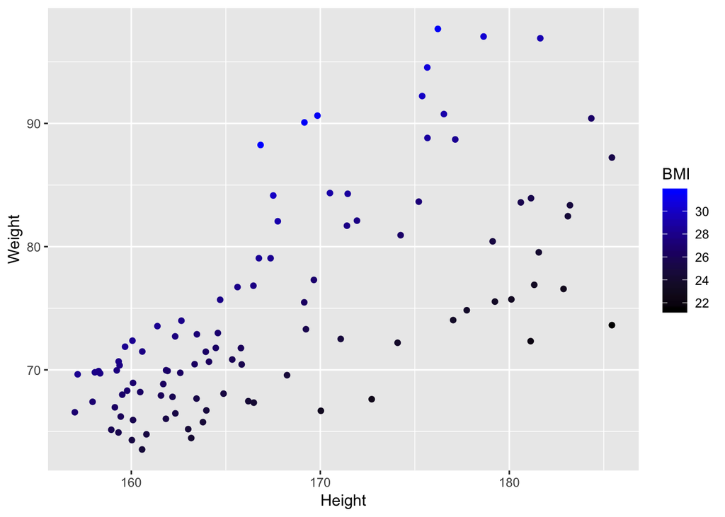

```r
ggplot(data = patients, mapping = aes(x = Height, y = Weight, colour = BMI)) +
  geom_point() +
  scale_colour_gradient(low = "black", high = "blue")
```

In some cases it might make sense to specify two colour gradients either side of a mid-point.

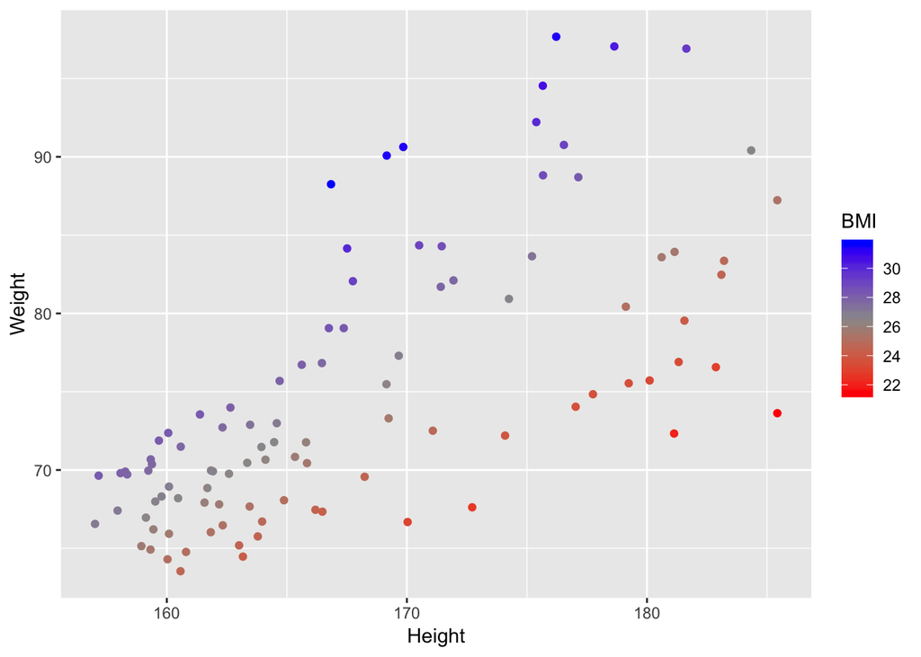

```r
ggplot(data = patients, mapping = aes(x = Height, y = Weight, colour = BMI)) +
  geom_point() +
  scale_colour_gradient2(low = "red", mid = "grey60", high = "blue", midpoint = median(patients$BMI))
```

As before we can override the default labels and other aspects of the BMI scale within the scale function.

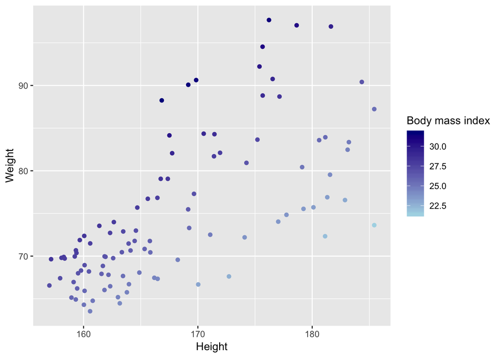

```r
ggplot(data = patients, mapping = aes(x = Height, y = Weight, colour = BMI)) +
  geom_point() +
  scale_colour_gradient(
    low = "lightblue", high = "darkblue",
    name = "Body mass index",
    breaks = seq(20, 30, by = 2.5)
  )
```

### Order of categories

Quite often we want to reorder the categories. For example, we might want males to be displayed on the left hand side in the following plot.

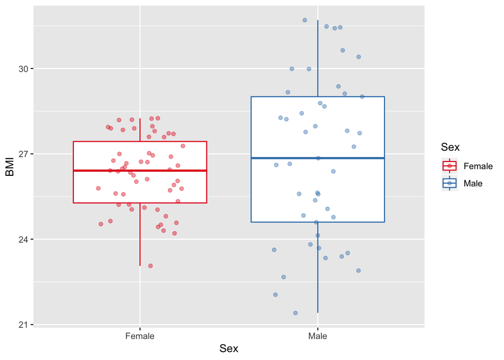

```r
ggplot(data = patients, mapping = aes(x = Sex, y = BMI, colour = Sex)) +
  geom_boxplot() +
  geom_jitter(width = 0.25, alpha = 0.4) +
  scale_colour_brewer(palette = "Set1")
```

Categorical variables are treated as special types of variables in R known as factors. A factor has levels, e.g. Female and Male for the Sex variable in the patients dataset.

ggplot2 displays categories in the order given by the levels of the factor. If a character variable is presented to ggplot2 as if it were a factor, ggplot2 converts it into a factor temporarily in order to create the plot, and the categories will be in alphabetical order.

We can reorder the categories by explicitly creating a factor with the levels set in our preferred order.

```r
patients$Sex
```

```
##   [1] Male   Male   Male   Male   Female Female Female Female Male   Male
##  [11] Female Female Male   Female Female Male   Male   Male   Male   Male
##  [21] Male   Female Male   Female Female Male   Male   Male   Male   Male
##  [31] Female Male   Male   Female Male   Female Male   Female Male   Female
##  [41] Male   Female Female Female Female Female Female Female Male   Female
##  [51] Female Female Female Female Male   Female Female Female Male   Male
##  [61] Female Male   Female Male   Male   Female Male   Female Male   Female
##  [71] Female Male   Male   Female Male   Female Male   Male   Female Female
##  [81] Female Female Male   Female Female Female Female Male   Female Male
##  [91] Male   Male   Female Male   Female Female Female Female Female Female
## Levels: Female Male
```

```r
patients$Sex <- factor(patients$Sex, levels = c("Male", "Female"))
```

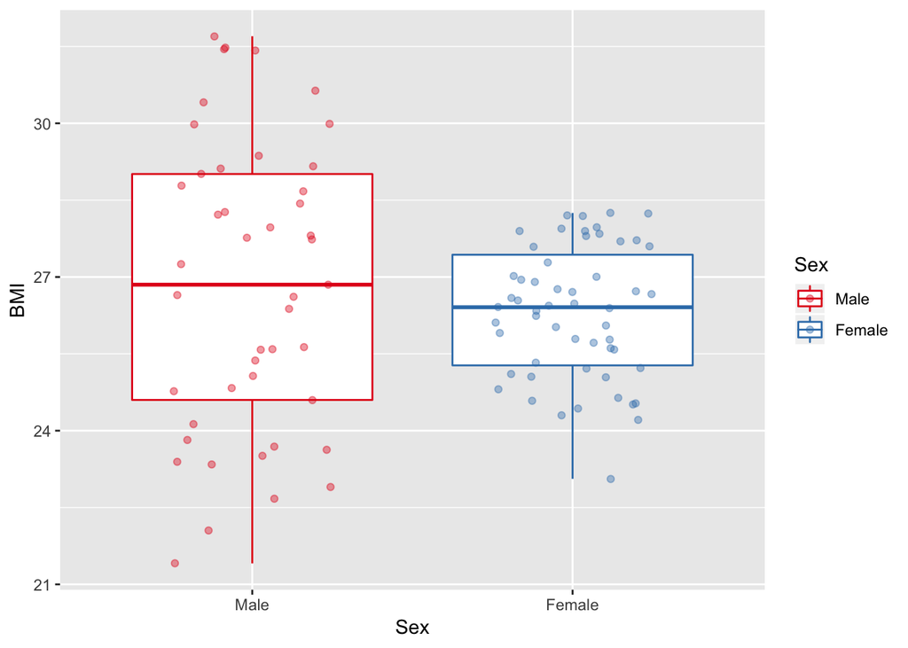

```r
ggplot(data = patients, mapping = aes(x = Sex, y = BMI, colour = Sex)) +
  geom_boxplot() +
  geom_jitter(width = 0.25, alpha = 0.4) +
  scale_colour_brewer(palette = "Set1")
```

The legend in this plot is not really necessary. We’ll see how to remove this in the next section on themes.

For plots where a legend is required, changing the order of levels in a factor will also change the ordering in the legend.

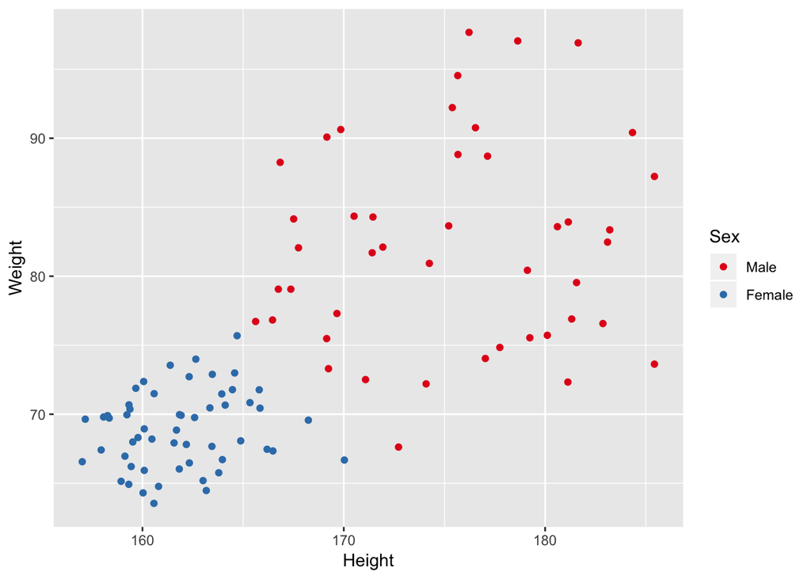

```r
ggplot(data = patients, mapping = aes(x = Height, y = Weight, colour = Sex)) +
  geom_point() +
  scale_colour_brewer(palette = "Set1")
```

## Themes

Themes can be used to customize non-data elements of your plot.

The black and white theme produces plots that are more suitable for articles that will be printed.

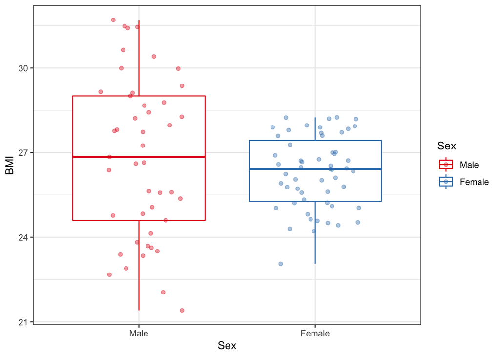

```r
ggplot(data = patients, mapping = aes(x = Sex, y = BMI, colour = Sex)) +
  geom_boxplot() +
  geom_jitter(width = 0.25, alpha = 0.4) +
  scale_colour_brewer(palette = "Set1") +
  theme_bw()
```

What other themes are there? Use RStudio auto-complete to see, try some of these and see how they look. The library `ggthemes` provides a few more.

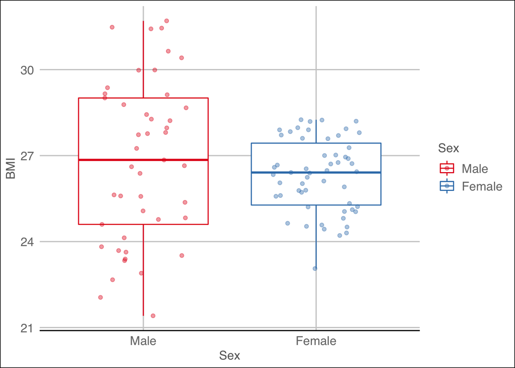

```r
library(ggthemes)
ggplot(data = patients, mapping = aes(x = Sex, y = BMI, colour = Sex)) +
  geom_boxplot() +
  geom_jitter(width = 0.25, alpha = 0.4) +
  scale_colour_brewer(palette = "Set1") +
  theme_gdocs()
```

The theme function can be used to modify individual components of a theme.

For example, the following will turn off the legend.

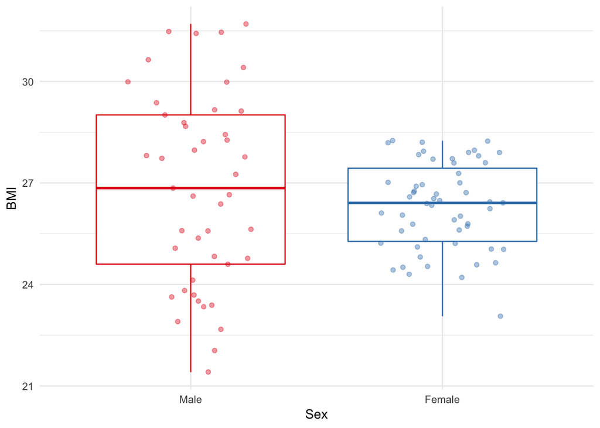

```r
ggplot(data = patients, mapping = aes(x = Sex, y = BMI, colour = Sex)) +
  geom_boxplot() +
  geom_jitter(width = 0.25, alpha = 0.4) +
  scale_colour_brewer(palette = "Set1") +
  theme_minimal() +
  theme(legend.position = "none")
```

Or we could place the legend somewhere else.

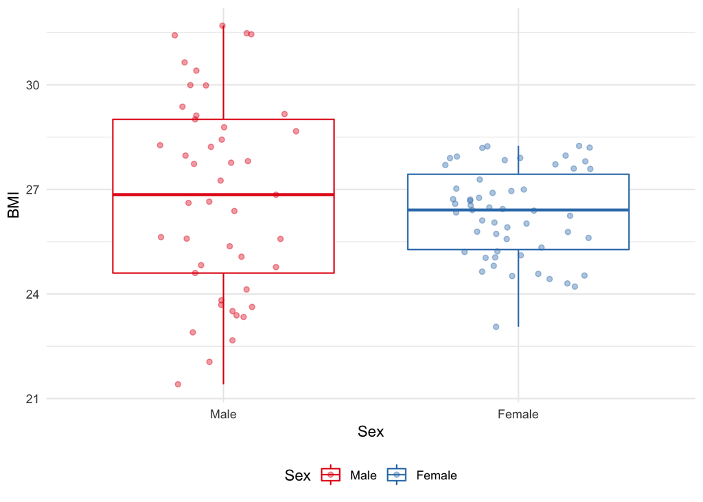

```r
ggplot(data = patients, mapping = aes(x = Sex, y = BMI, colour = Sex)) +
  geom_boxplot() +
  geom_jitter(width = 0.25, alpha = 0.4) +
  scale_colour_brewer(palette = "Set1") +
  theme_minimal() +
  theme(legend.position = "bottom")
```

Use the help page for the `theme` function to see what else can be changed (quite a lot!).

```r
?theme
```

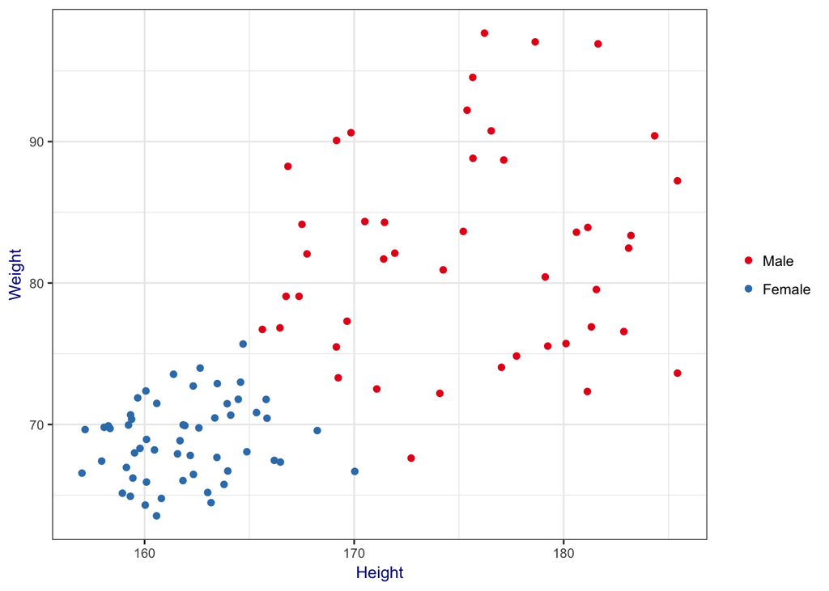

```r
ggplot(patients, mapping = aes(x = Height, y = Weight, colour = Sex)) +
  geom_point() +
  scale_colour_brewer(palette = "Set1") +
  theme_bw() +
  theme(
    axis.title = element_text(size = 10, colour = "darkblue"),
    axis.text = element_text(size = 8),
    legend.title = element_blank()
  )
```

## Statistical transformations

Many graphs, like scatterplots, plot the raw values from your dataset; other graphs, like bar charts, calculate new values to plot.

- bar charts and histograms (`geom_bar`, `geom_histogram`, `geom_freqpoly`) bin your data and then plot bin counts
- smoothing functions (`geom_smooth`) fit a model to your data and then plot predictions from the model
- box plots (`geom_boxplot`) compute a robust summary of the distribution and display a specially formatted box

The algorithm used to calculate new values for a graph is called a `stat`

Take a look at the help page for `geom_bar`.

```r
?geom_bar
```

Note that it uses a “count” stat.

Sometimes you might want to override a stat, e.g. when you want to display a bar chart but already have counts.

```r
state_counts <- count(patients, State)
state_counts
```

```
## # A tibble: 6 x 2
##   State          n
##   <fct>      <int>
## 1 California    10
## 2 Colorado      15
## 3 Georgia       16
## 4 Indiana       18
## 5 New Jersey    20
## 6 New York      21
```

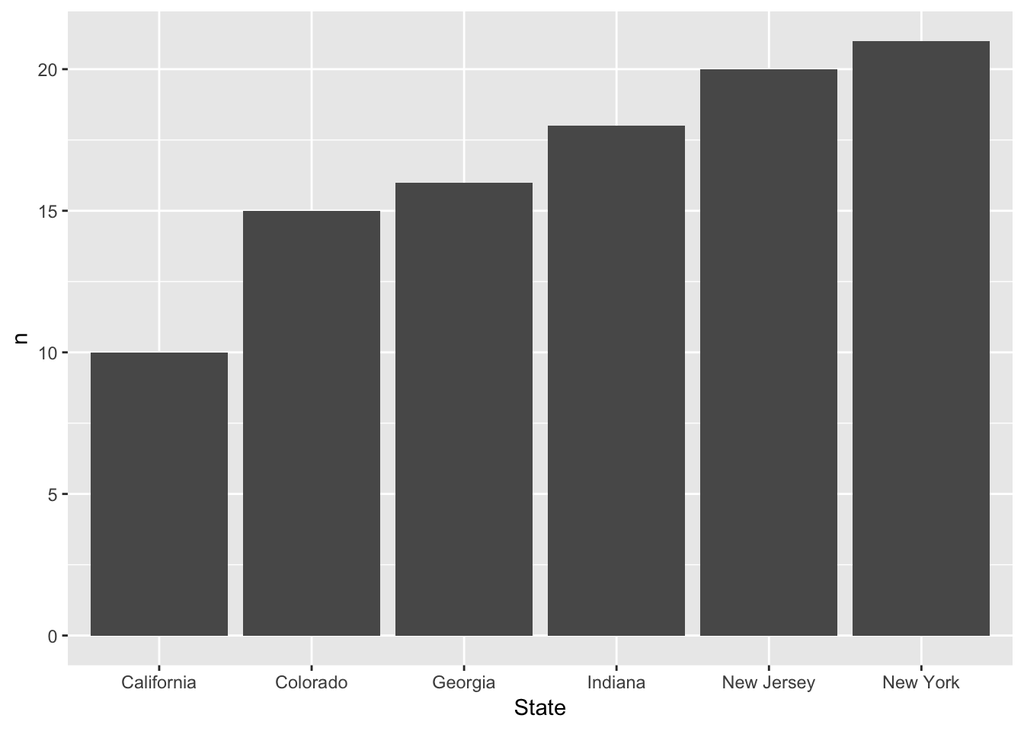

```r
ggplot(data = state_counts, mapping = aes(x = State, y = n)) +
  geom_bar(stat = "identity")
```

Compare this with the following bar chart for which we have observations for each patient rather than a summary of the numbers of each state.

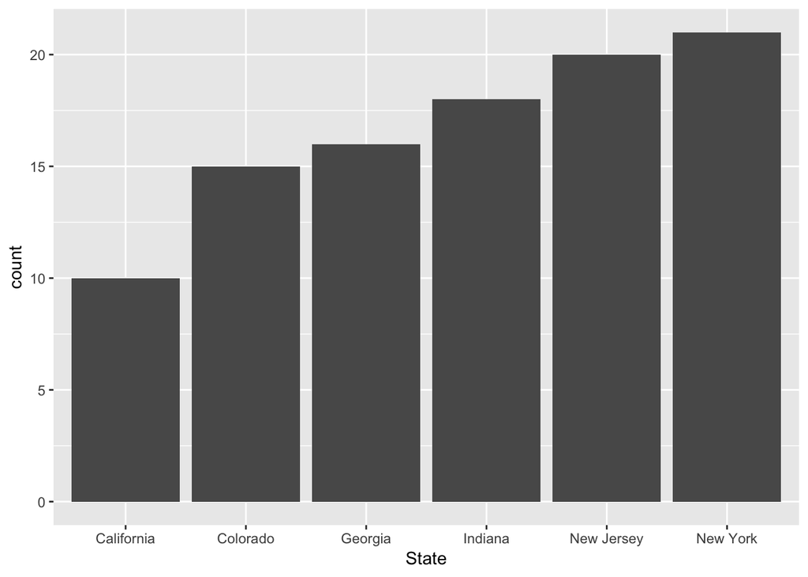

```r
ggplot(data = patients, mapping = aes(x = State)) +
  geom_bar(stat = "count")
```

By default `geom_bar` applies the statistical transformation, `stat_count`, in much the same way as we did above to create the `state_counts` summary table.

## Position adjustments

Earlier we created the following stacked bar chart by setting the `fill` aesthetic in a `geom_bar` to a categorical variable. Let’s revisit this.

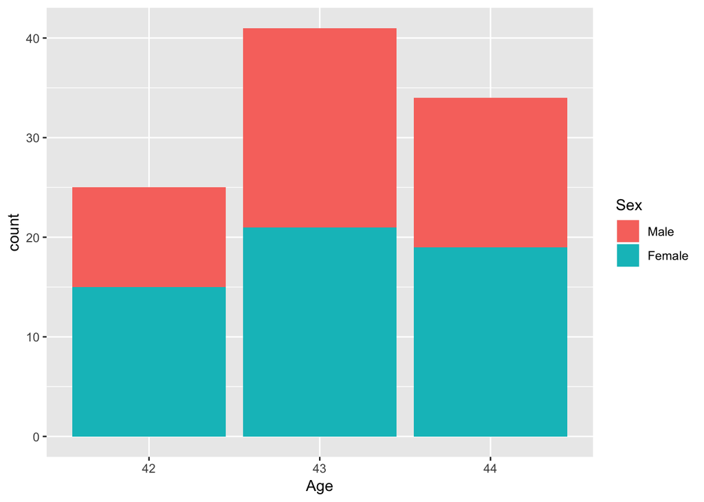

```r
ggplot(data = patients, mapping = aes(x = Age, fill = Sex)) +
  geom_bar()
```

We can control the way stacking is performed by specifying a position adjustment using the `position` argument.

For example, to place the bars for the separate categories side-by-side we can use `position = "dodge"`.

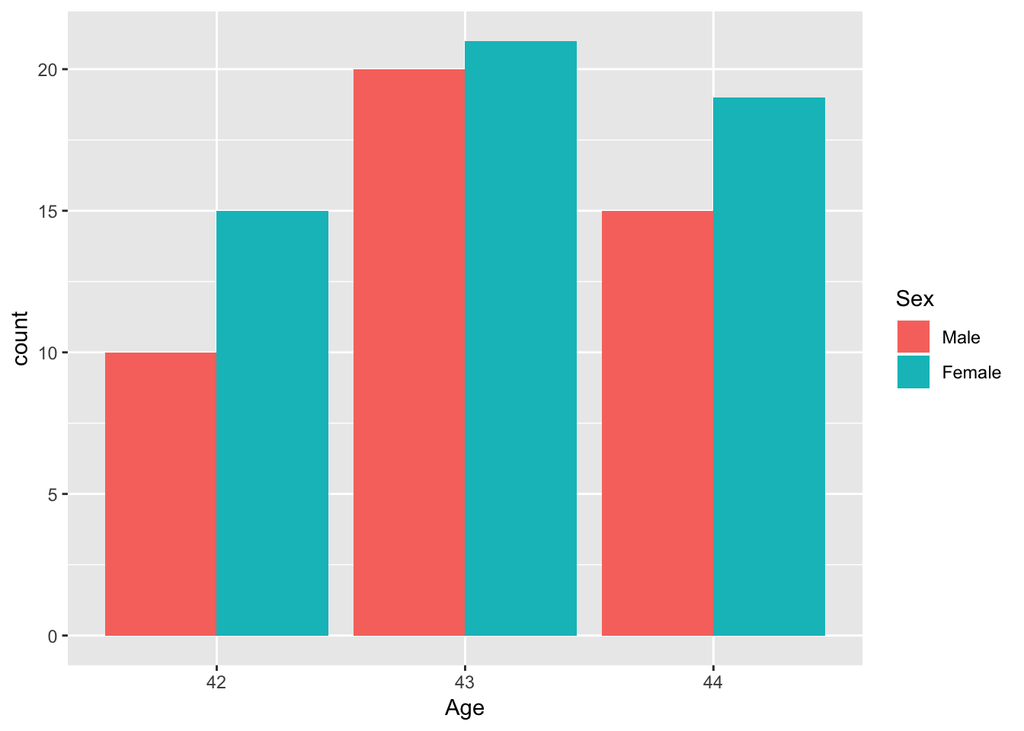

```r
ggplot(data = patients, mapping = aes(x = Age, fill = Sex)) +
  geom_bar(position = "dodge")
```

Try some of the other values for the position adjustment, e.g. `"fill"` and `"identity"`,

Another type of position adjustment is `"jitter"`. This is much more useful for scatter plots than for bar charts. We already used `geom_jitter` to separate points added to a box plot and using `position = "jitter"` in `geom_point()` is similar.

`position = "jitter"` adds a small amount of random noise to each point and is especially useful for data sets that contain multiple observations with the same x and y values, e.g. where these are discrete. The patients dataset isn’t really a good example of where this would be needed so let’s take a look at the `mpg` data frame that ggplot2 provides as a test dataset.

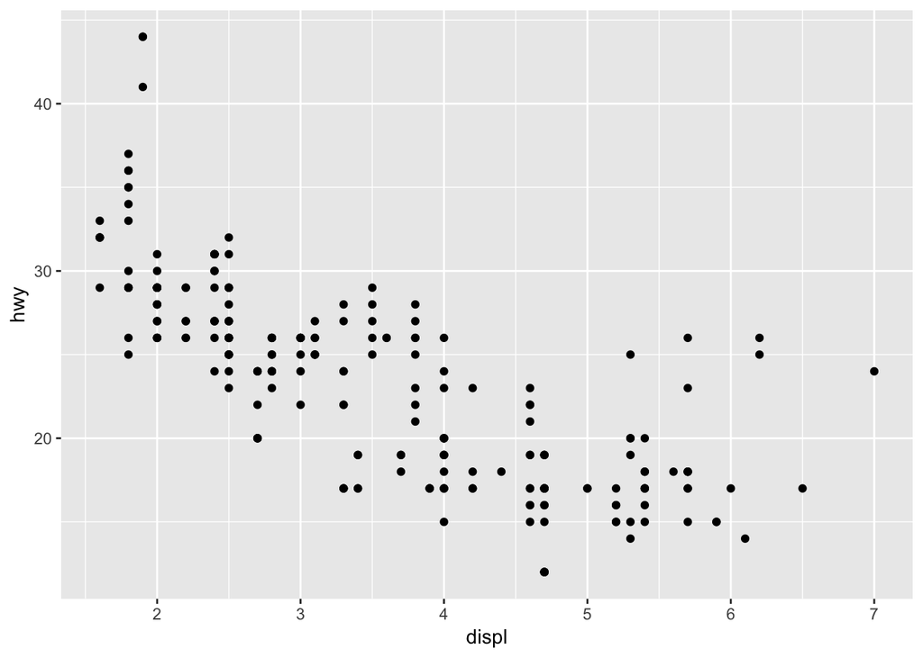

```r
ggplot(data = mpg, mapping = aes(x = displ, y = hwy)) +
  geom_point()
```

The `mpg` data frame has 234 observations but there are clearly not 234 points on this scatter plot; there are more than one observation with the same value of `displ` and `hwy`.

`position = "jitter"` separates the overlapping points.

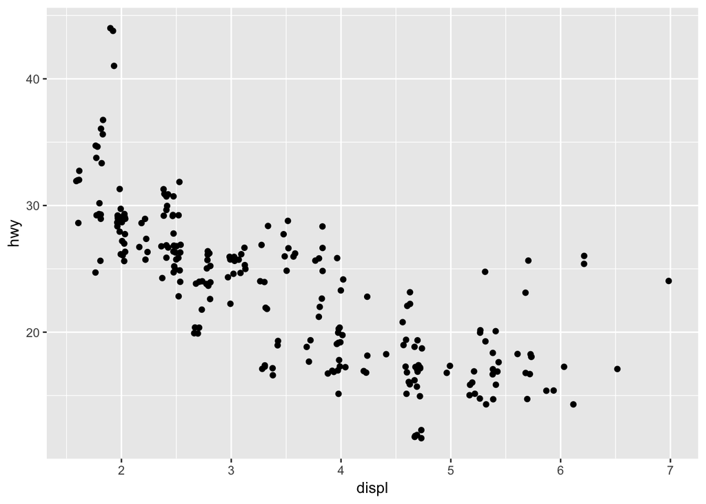

```r
ggplot(data = mpg, mapping = aes(x = displ, y = hwy)) +
  geom_point(position = "jitter")
```

## Saving plots

Use `ggsave` to save the last plot you displayed.

```r
ggsave("myplot.png")
```

Alternatively, `ggsave` can be passed an explicit plot object.

```r
plot <- ggplot(data = patients, mapping = aes(x = Smokes, y = BMI, colour = Smokes)) +
  geom_boxplot() +
  geom_jitter(alpha = 0.4, width = 0.25) +
  facet_wrap(~ Sex) +
  scale_colour_brewer(palette = "Set1") +
  theme(legend.position = "none")

ggsave("myplot.png", plot)
```

The type of plot file, e.g. pdf, svg, png, etc., and the dimensions can be specified, e.g.

```r
ggsave("myplot.pdf", width = 8, height = 6)
```

## Exercises part III - scales and themes

See separate R markdown document.